# Explainable AI (XAI): Global Methods

**Author:** Martin Beneš

This is a demo for global methods in XAI for course 703326: Advanced Machine Learning.

We show how generate saliency map for images and CNN using PyTorch and Captum.

```python
import captum
import glob
import numpy as np
import matplotlib.pyplot as plt
import PIL.Image
import torch
import torchvision
import typing
```

The task is to distinguish cats vs. dogs.

## Cat-Dog Dataset

We start by loading the dataset with images of cats and dogs.

```python
class CatDogDataset(torch.utils.data.Dataset):
    """Class representing the Cat-Dog dataset."""
    def __init__(self, image_paths, transform=None, debug=False):
        """Constructor."""
        super().__init__()
        self.paths = image_paths
        self.transform = transform
        self.debug = debug

    def __len__(self) -> int:
        """Dataset size."""
        return len(self.paths)

    def __getitem__(self, index: int) -> typing.Tuple[torch.tensor, int]:
        """Indexing dataset."""
        path = self.paths[index]
        label = int('dog' in path.split('/')[-1])  # dog 1, cat 0
        if self.debug:
            return (path, label)
        image = PIL.Image.open(path).convert('RGB')
        if self.transform:
            image = self.transform(image)
        return (image, label)
```

For occlusion, we use the validation dataset (it was not used for training).

The images are subsampled to $128\times128$, and converted to floats.

```python
# filenames
va_files = glob.glob('cats_and_dogs/validation/*/*')

# augmentation
transform = torchvision.transforms.Compose([
    torchvision.transforms.Resize((128, 128)),  # bilinear subsampling with AA
    torchvision.transforms.ToTensor(),
    torchvision.transforms.Normalize((0.5,), (0.5,))  # normalize
])

# create dataset and data loader
va_dataset = CatDogDataset(va_files, transform=transform)
va_dataloader = torch.utils.data.DataLoader(
    va_dataset,
    batch_size=32,
    shuffle=True,
    num_workers=4,
    pin_memory=True)
```

## ResNet-based Model

We use trained ResNet18 model. It was transferred from ImageNet and fine-tuned to our dataset.

All we do here is load the trained weights.

```python
# get ResNet model
model_resnet18 = torchvision.models.get_model('resnet18')
# FC layer
model_resnet18.fc = torch.nn.Sequential(
    torch.nn.Linear(model_resnet18.fc.in_features, 512),
    torch.nn.ReLU(),
    torch.nn.Dropout(),
    torch.nn.Linear(512, 2)
)

# move to device
device = torch.device("cuda" if torch.cuda.is_available() else 'cpu')
model_resnet18 = model_resnet18.to(device)

# load pretrained cat-dog weights
model_resnet18.load_state_dict(torch.load('./resnet18_catdog.pth'));
```

## Evaluate

Just to see that the model is correctly trained, we evaluate its performance on the validation dataset.

```python
# evaluate for validation dataset
correct, total = 0, 0
model_resnet18.eval()
with torch.no_grad():

    # iterate batches
    for batch in va_dataloader:
        inputs, targets = map(lambda i: i.to(device), batch)

        # forward-pass
        outputs = model_resnet18(inputs)
        _, predicted = torch.max(outputs.data, 1)

        # score
        total += targets.size(0)
        correct += (predicted == targets).sum().item()

# print
print('correct: {:d}  total: {:d}'.format(correct, total))
print('accuracy = {:f}'.format(correct / total))
```

```
correct: 956  total: 1000
accuracy = 0.956000
```

Accuracy is 95.6%, same as reported during training. Model seems to be loaded correctly.

## Explain with saliency maps

Our goal is to generate saliency maps for selected images and analyze them.

```python
def single_image_batch(fname):
    """Image to single-image batch."""
    # read
    im = PIL.Image.open(fname).convert('RGB')
    # transform
    im = transform(im)
    # add batch axis
    return torch.unsqueeze(im, 0)
```

We select 1 image of dog and 1 image of cat with nicely exposed faces, which yield nice saliency maps.

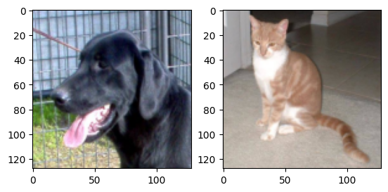

```python
# get single samples
batch_dog = single_image_batch(va_files[14])
batch_cat = single_image_batch(va_files[-2])
batch_cat = single_image_batch(va_files[-6])

# convert to numpy
x_dog = batch_dog[0].numpy().transpose(1, 2, 0) * .5 + .5
x_cat = batch_cat[0].numpy().transpose(1, 2, 0) * .5 + .5
# plot
fig, ax = plt.subplots(1, 2)
ax[0].imshow(x_dog)
ax[1].imshow(x_cat)
plt.show()
```

The occlusion takes the model. We also need to select several parameters, such as window shape, value and stride.

We choose, how we want to visualize our saliency map.

```python
# pass model to occlusion
xai = captum.attr.Occlusion(model_resnet18)

# occlusion parameters
sliding_window_shapes=(3, 30, 30)  # area to cover
baselines = 0  # cover value
strides = (3, 3, 3)  # fine-ness vs. speed

# visualization
vis_types = ["original_image", "masked_image"]  # heat_map, blended_heat_map, alpha_scaling
vis_signs = ["all", "positive"]  # absolute_value, negative
```

We start with the dog sample.

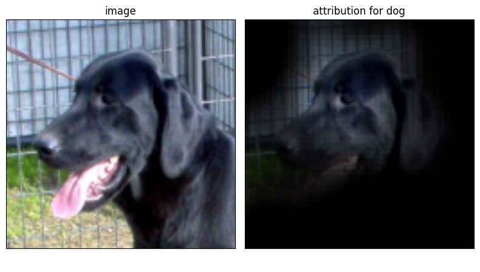

```python
# compute attribution for a batch (dog image)
attribution_dog = xai.attribute(
    batch_dog.to(device),
    target=1,
    strides=strides,
    sliding_window_shapes=sliding_window_shapes,
    baselines=baselines,
)

# visualize
_ = captum.attr.visualization.visualize_image_attr_multiple(
    attribution_dog.squeeze().cpu().detach().numpy().transpose(1, 2, 0),
    x_dog,
    vis_types,
    vis_signs,
    ["image", "attribution for dog"],
    show_colorbar = True
)
```

For the dog, it seems the shape of the head is important. It could be also the eyes, or ears, or combination of all.

Next is the cat image.

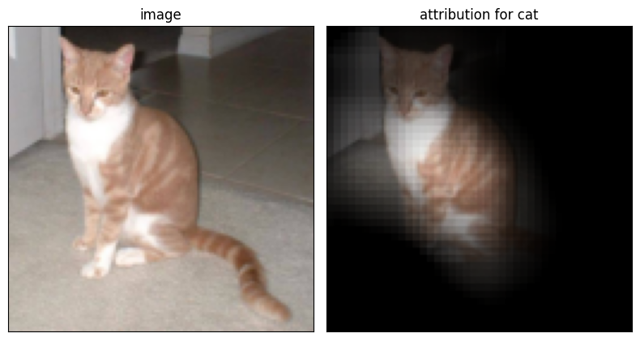

```python
# compute attribution for a batch (cat image)
attribution_cat = xai.attribute(
    batch_cat.to(device),
    target=0,
    strides=strides,
    sliding_window_shapes=sliding_window_shapes,
    baselines=baselines,
)

# visualize
_ = captum.attr.visualization.visualize_image_attr_multiple(
    attribution_cat.squeeze().cpu().detach().numpy().transpose(1, 2, 0),
    x_cat,
    vis_types,
    vis_signs,
    ["image", "attribution for cat"],
    show_colorbar = True
)
```

The model seems to look at the body and neck of the cat, less at its face.

## Shortcuts in learning

Problematic dataset can allow the model to learn unintentional shortcuts.

> Cats are on a grass, dogs are on a carpet.

> Fraudulent transactions with the old system take longer to process.

> Stego images are always taken with the same camera.

Problem of *sampling bias* may lead to *spurious correlations*.